# Polymorphism

## Polymorphism

The dictionary definition of polymorphism refers to a principle in biology in which an organism or species can have many different forms or stages. This principle can also be applied to object-oriented programming and languages like the Java language. Subclasses of a class can define their own unique behaviors and yet share some of the same functionality of the parent class.

Polymorphism improves code organization and readability as well as the creation of extensible programs that can be “grown” not only during the original creation of the project, but also when new features are desired.

**Polymorphism** is an ability of a program to use different objects with the same interface without information about a concrete type of these objects.

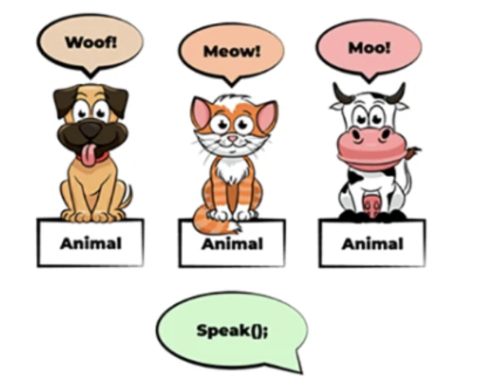

Let's consider this example:

```java
abstract class Animal {
    String type;
    abstract void speak();
}
```

We have an abstract class Animal with only one abstract method `speak()`. So far we don't have any information about type of this animal and how it can "speak". Now we will create several concrete classes which will inherit from our **Animal** class.

```java
class Cat extends Animal {

    public Cat() {
        this.type = "Cat";
    }

    void speak() {
        System.out.println(type + " says: Meow!");
    }

    void something() {

    }
}
```

```java
class Dog extends Animal {

    public Dog() {
        this.type = "Dog";
    }

    void speak() {
        System.out.println(type + " says: Woof!");
    }
}
```

```java
class Cow extends Animal {

    public Cow() {
        this.type = "Cow";
    }

    void speak() {
        System.out.println(type + " says: Moo!");
    }
}
```

As you can see we have 3 different classes which are animals in nature. They all have method `speak()` that was inherited from **Animal** class.

Now we will see where polymorphism is used.

```java
Animal cat = new Cat();
Animal dog = new Dog();
Animal cow = new Cow();

cat.speak();
dog.speak();
cow.speak();
```

```
Cat says: Meow!
Dog says: Woof!
Cow says: Moo!
```

3 different objects have 3 different implementations of speak() method. We use reference variable of type "Animal" to refer different objects that inherit from "Animal".

Lets consider another example, with arrays. We need to create an array of different animals.

```java
Animal[] myAnimals = new Animal[5];
```

After we created a new array of the type "Animal" we can put in any object which inherits from Animal.

```java
Animal tom = new Cat();
Animal bart = new Cat();
Animal spike = new Dog();
Animal rover = new Dog();
Animal mooMoo = new Cow();
```

We created 5 different objects that inherits from our Animal class. Now we can put them in our array **myAnimals**.

```java
myAnimals[0] = tom;
myAnimals[1] = bart;
myAnimals[2] = spike;
myAnimals[3] = rover;
myAnimals[4] = mooMoo;
```

```
REPL.$JShell$15E$Cow@9c9ffad
```

Let's iterate over all animals in our array and call the method `speak()`:

```java
for (Animal animal : myAnimals) {
    animal.speak();
}
```

```
Cat says: Meow!
Cat says: Meow!
Dog says: Woof!
Dog says: Woof!
Cow says: Moo!
```

When we iterate over all the objects in the **myAnimals** array, every object will be upcasted to the its base type **Animal**. So all our different types of objects in **myAnimals** array will be referenced via a base type reference variable. But what it really means? Let's dive into it.

```java
abstract class Device {
    abstract void on();
    abstract void off();
}
```

```java
class TV extends Device {
    void on() {
        System.out.println("TV is on.");
    }
    void off() {
        System.out.println("TV is off.");
    }
    void changeChannel(int newChannel) {
        System.out.println("Changing a channel to " + newChannel);
    }
}
```

We have an abstract type **Device** and a concrete type of the device - **TV**. Now we create a new object of **TV** class and call all its methods.

```java
TV tv = new TV();
tv.on();
tv.changeChannel(10);
tv.off();
```

```
TV is on.
Changing a channel to 10
TV is off.
```

But if we try to do the following

```java
Device tv = new TV();
tv.on();
tv.changeChannel(5);
```

```
TV is on.
```

```
|   tv.changeChannel(5);
cannot find symbol
  symbol:   method changeChannel(int)
```

we will get a compile-time error that no method **changeChannel** was found.

This is because we refer to our **TV** object via reference of type **Device**. But if we look at the class **Device** we won't find any method **changeChannels** in its declaration.

So if we use a base type reference for derived class objects, we will be able to use only those members which are declared in the base class.

### Casting

Recall from our previous lessons that the process of forcing a conversion from one type to another is called casting. The Java programming language has a special notation for casts. For example,

```java
double pi = 3.14;
int intPi = (int) pi;
intPi
```

```
3
```

Just as you occasionally need to convert a floating-point number to an integer, you may need to convert an object reference from one class to another.

To actually make a cast of an object reference, use a syntax similar to what you use for casting numeric expressions. Surround the target class name with parentheses and place it before the object reference you want to cast. For example:

```java
class Employee {
    void print() {
        System.out.println("I'm an employee");
    }
}
class Manager extends Employee {

    @Override
    void print() {
        System.out.println("I'm a manager");
    }

    void doWork() {
        System.out.println("Doing managers work");
    }
}
```

```java
Employee manager = new Manager();
manager.print();
manager.doWork();
```

```
I'm a manager
```

```
|   manager.doWork();
cannot find symbol
  symbol:   method doWork()
```

In spite of the fact that we created a Manager object, we cannot use its **doWork** method because we refer to it via **Employee** type reference. It's time to cast it.

```java
manager.print();
((Manager)manager).doWork();
```

```
I'm a manager
Doing managers work
```

Now everything works fine.

But you cannot do the following:

```java
Employee managerDima = new Employee();
managerDima.print();
((Manager)managerDima).doWork();
```

```
I'm an employee
```

```
---------------------------------------------------------------------------
java.lang.ClassCastException: class REPL.$JShell$13$Employee cannot be cast to class REPL.$JShell$14$Manager (REPL.$JShell$13$Employee and REPL.$JShell$14$Manager are in unnamed module of loader jdk.jshell.execution.DefaultLoaderDelegate$RemoteClassLoader @71809907)
	at .(#22:1)
```

The casting of the reference type variable from the base class type to a derived class type is called **Downcasting**.

There is only one reason why you would want to make a downcating — to use an object in its full capacity after its actual type has been temporarily forgotten.

### instanceof keyword

Now we extend our program with a new employee type **CEO**.

```java
class CEO extends Employee {
    void print() {
        System.out.println("I'm a CEO");
    }

    void manageCompany() {
        System.out.println("Managing the company");
    }
}
```

```java
Employee[] stuff = new Employee[10];
Random random = new Random();

for (int i = 0; i < 10; i++) {
    int rand = random.nextInt(3);
    if (rand == 0) {
        stuff[i] = new Employee();
    } else if (rand == 1) {
        stuff[i] = new Manager();
    } else {
        stuff[i] = new CEO();
    }
}
```

```java
for (Employee employee : stuff) {
    employee.print();
}
```

```
I'm a CEO
I'm an employee
I'm a manager
I'm an employee
I'm a manager
I'm a CEO
I'm a manager
I'm a CEO
I'm a CEO
I'm an employee
```

Now we have different types of employees in our array. They are all referenced via a base type reference "Employee" therefore we cannot call their methods **doWork()** and **manageCompany()**. For doing so we need to cast them to appropriate type. But how can we know what object we can cast to what type? We can use **instanceof** keyword for this purpose:

```java
for (Employee employee: stuff) {
    if (employee instanceof Manager) {
        ((Manager)employee).doWork();
    } else if (employee instanceof CEO) {
        ((CEO)employee).manageCompany();
    }
}
```

```
Managing the company
Doing managers work
Doing managers work
Managing the company
Doing managers work
Managing the company
Managing the company
```